# Survival Analysis: NCCTG Lung Cancer Cohorte

Abderrezzaq KADOUCHE

## **Présentation de l’étude**

Ce jeu de données provient d’une étude multicentrique menée par le North Central Cancer Treatment Group (NCCTG) portant sur la survie de patients atteints d’un cancer du poumon avancé.

## **Questions de recherche**

Cette analyse vise à répondre à deux questions :

1. La survie diffère-t-elle selon le sexe des patients ?
2. Quels sont les facteurs pronostiques associés à la survie ?

## **Les variables étudiées**

| Variable | Description | Codage / Unités |
| --- | --- | --- |
| `inst` | Code de l’institution | Numérique |
| `time` | Temps de survie | En jours |
| `status` | Statut de censure | 1 = censuré, 2 = décédé |
| `age` | Âge | En années |
| `sex` | Sexe | 1 = homme, 2 = femme |
| `ph.ecog` | Score de performance ECOG évalué par le médecin | 0 = asymptomatique ; 1 = symptomatique mais complètement ambulatoire ; 2 = alité < 50 % de la journée ; 3 = alité > 50 % de la journée mais pas grabataire ; 4 = grabataire |
| `ph.karno` | Score de performance de Karnofsky évalué par le médecin | 0 (mauvais) à 100 (bon) |
| `pat.karno` | Score de performance de Karnofsky évalué par le patient | 0 (mauvais) à 100 (bon) |
| `meal.cal` | Calories consommées lors des repas | Kilocalories |
| `wt.loss` | Perte de poids au cours des six derniers mois | Livres (pounds) |

## **Description des variables quantitatives**

```r
library (prettyR)

vars_quanti <- c("age", "ph.karno", "pat.karno", "meal.cal", "wt.loss")

describe(lung[,vars_quanti], num.desc=c("min", "max", "mean", "median", "sd", "valid.n"))
```

```
## Description of lung[, vars_quanti]
```

```
##
##  Numeric
##           min  max   mean median     sd valid.n
## age        39   82  62.45     63   9.07     228
## ph.karno   50  100  81.94     80  12.33     227
## pat.karno  30  100  79.96     80  14.62     225
## meal.cal   96 2600 928.78    975 402.17     181
## wt.loss   -24   68   9.83      7  13.14     214
```

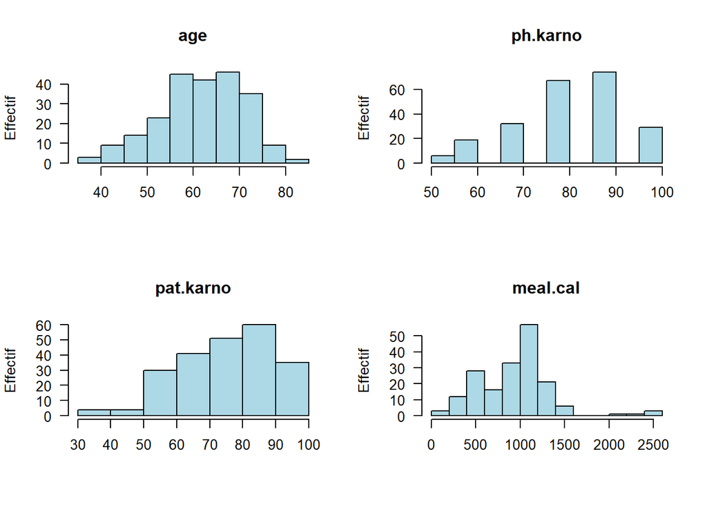

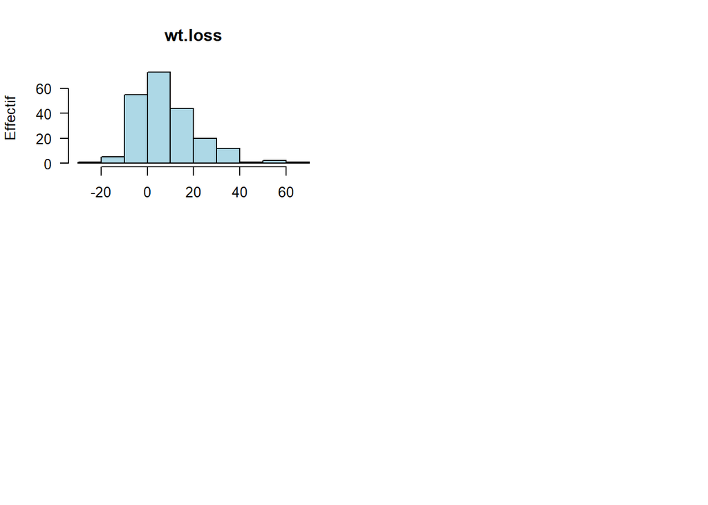

```r
#La distribution de ces variables quantitatives (Représentation graphique en HISTOGRAMME)

par(mfrow=c(2,2))

for(var in vars_quanti) {
  hist(lung[[var]],
       main = var,    # Titre = nom de la variable
       xlab = "",   # Pas de label sur l'axe X
       ylab="Effectif",
       las=1,
       col = "lightblue")}
```

## **Description des variables qualitatives**

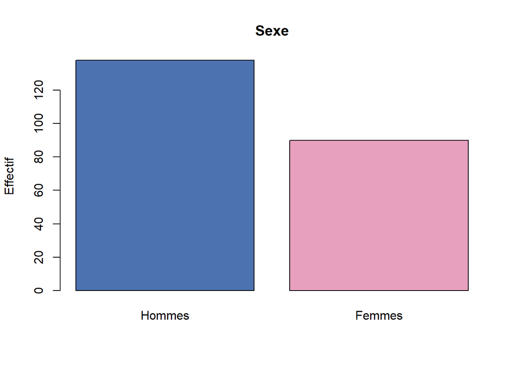

```r
par(mfrow = c(1, 1))

barplot(   table(lung$sex),    main = "Sexe",    ylab = "Effectif",    col  = c("#4C72B0", "#E8A0BF"),   names.arg = c("Hommes", "Femmes")    )
```

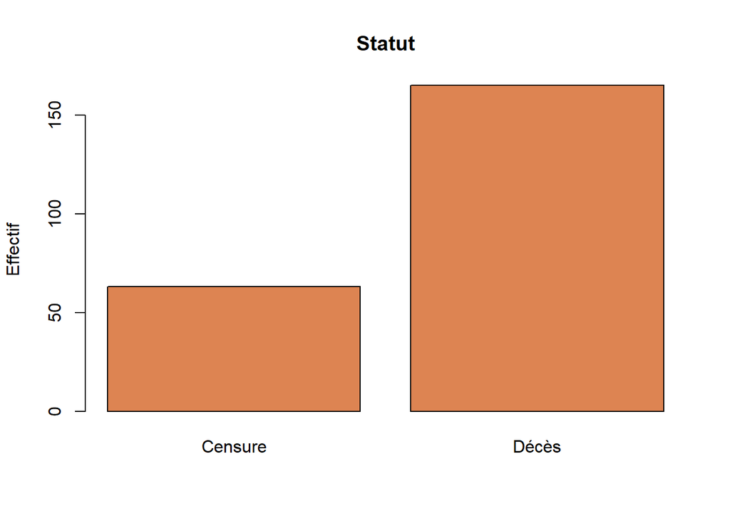

```r
barplot(   table(lung$status),    main = "Statut",     col = "#DD8452",    ylab = "Effectif",   names.arg = c("Censure", "Décès")    )
```

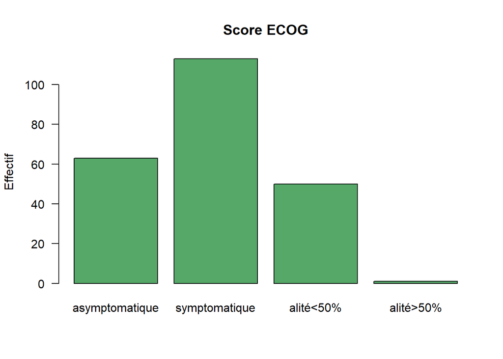

```r
barplot(   table(lung$ph.ecog),
           main = "Score ECOG",
           col = "#55A868",
           ylab = "Effectif",
           las = 1,
           names.arg = c("asymptomatique",
                         "symptomatique",
                         "alité<50%",
                         "alité>50%")
           )
```

## **Les données manquantes**

```r
tab_NA <- data.frame(
  Variables = names(lung),
  n_NA = colSums(is.na(lung)),
  percent_NA = round(colMeans(is.na(lung)) * 100, 2),
  row.names = NULL )

print(tab_NA)
```

```
##    Variables n_NA percent_NA
## 1       inst    1       0.44
## 2       time    0       0.00
## 3     status    0       0.00
## 4        age    0       0.00
## 5        sex    0       0.00
## 6    ph.ecog    1       0.44
## 7   ph.karno    1       0.44
## 8  pat.karno    3       1.32
## 9   meal.cal   47      20.61
## 10   wt.loss   14       6.14
```

## **Gestion des données manquantes**

Les données manquantes ont été gérées par imputation multiple, sous l’hypothèse que le mécanisme est de type MAR.

## **Les courbes de survie: Kaplan-Meier**

- La censure est supposée non informative. Cette hypothèse est supposée vérifiée dans cette cohorte pour valider l’utilisation du modèle.
- Le **test du log-rank** met en évidence une différence de survie statistiquement significative entre les hommes et les femmes (p = 0,0013).

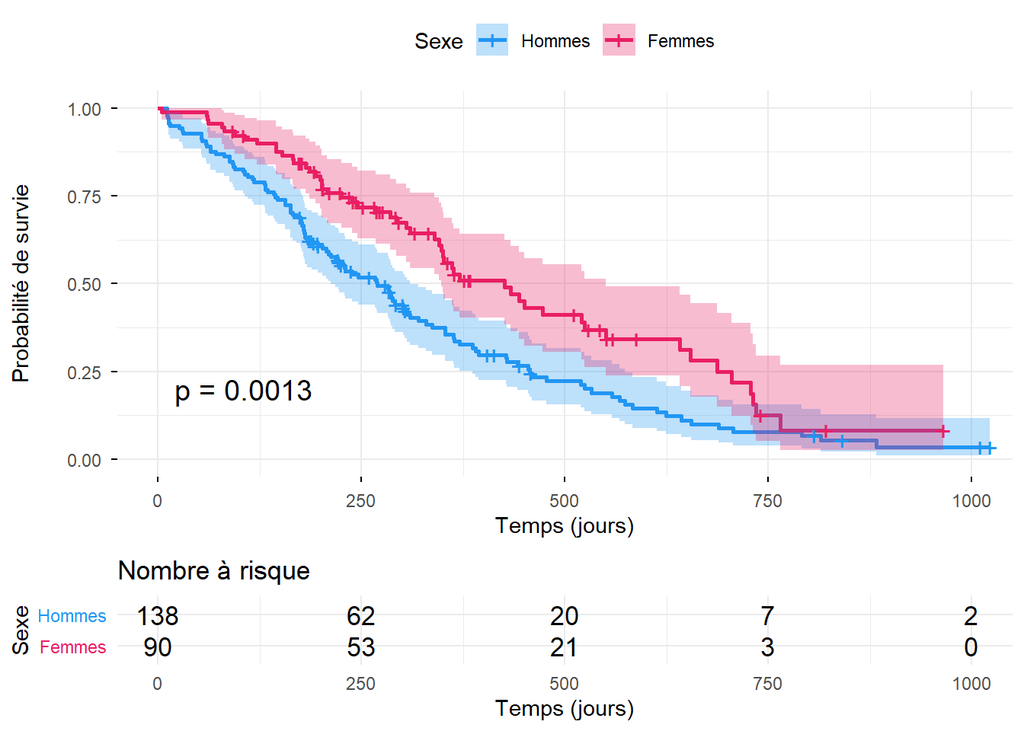

```r
#1) KAPLAN MEIER & LOG-RANK : pour visualiser et comparer les courbes de survie

library(survival)
library(survminer)
library(tidyverse)

# Ajustement du modèle de Kaplan-Meier

fit <- survfit(   Surv(time= time, event= status) ~ sex,   data = lung )

#ensuite tracer les courbes de survie
lung$sex <- factor(lung$sex)

ggsurvplot(   fit,
              data = lung,
              conf.int = TRUE,
              pval = TRUE,
              risk.table = TRUE,
              ggtheme = theme_minimal(),
              legend.title = "Sexe",
              xlab         = "Temps (jours)",
              ylab         = "Probabilité de survie",
              legend.labs  = c("Hommes", "Femmes"),
              palette = c("#2196F3", "#E91E63"),
              risk.table.title = "Nombre à risque" )
```

## **Les médianes de survie**

- Chez les **hommes**, la moitié des patients est décédée à **270 jours** (~9 mois).
- Chez les **femmes**, la moitié des patients est décédée à **426 jours** (~14 mois).
- Les IC 95 % ne se chevauchent pas (212–310 vs 348–550) ce qui suggère une différence de survie **significative** entre les sexes, en faveur des femmes.

```r
library(dplyr)

surv_median(fit) %>%
  mutate(     Sexe = recode(strata,
                            "sex=1" = "Hommes",
                            "sex=2" = "Femmes")
              )%>%
  select(Sexe, median, lower, upper) %>%
  rename(     `Médiane (jours)` = median,
              `IC 95 % inf.`    = lower,
              `IC 95 % sup.`    = upper   )
```

```
##     Sexe Médiane (jours) IC 95 % inf. IC 95 % sup.
## 1 Hommes             270          212          310
## 2 Femmes             426          348          550
```

## **Vérification de l’hypothèse de proportionnalité des risques**

```
##            chisq df     p
## sex       2.4106  1 0.121
## age       0.0772  1 0.781
## wt.loss   1.1874  1 0.276
## meal.cal  1.7849  1 0.182
## ph.ecog   0.7700  1 0.380
## ph.karno  3.1819  1 0.074
## pat.karno 2.8664  1 0.090
## GLOBAL    8.3272  7 0.305
```

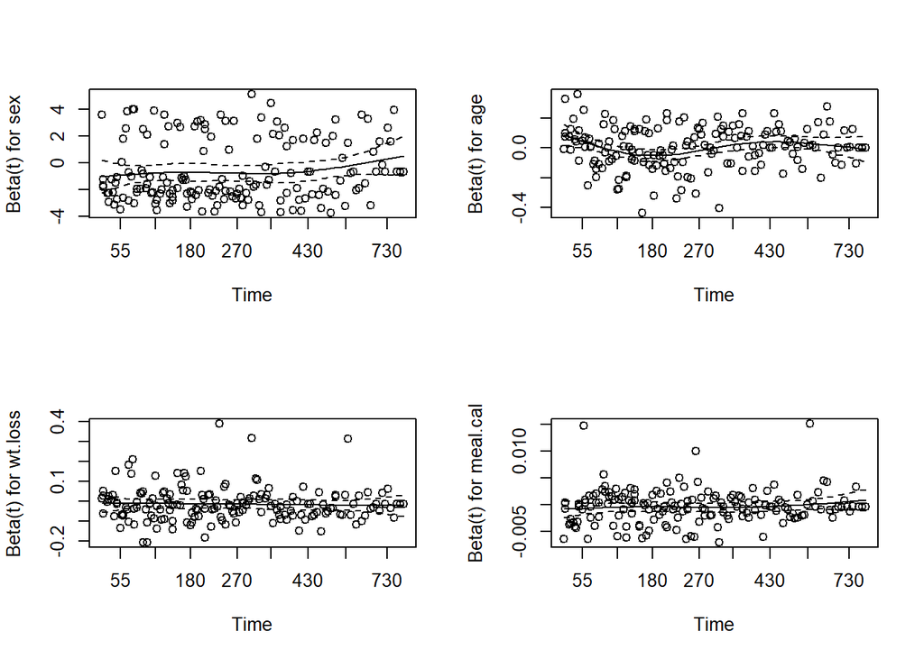

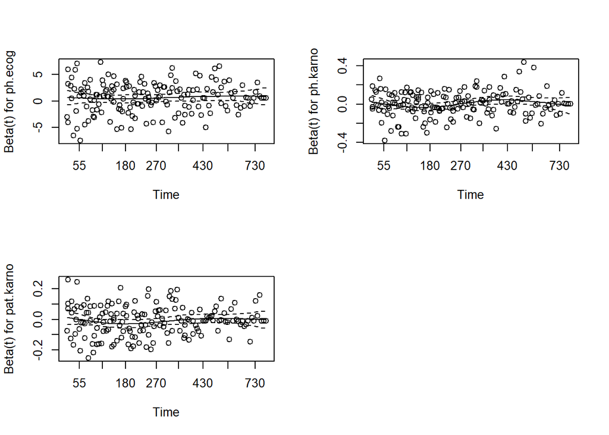

## **Vérification de l’hypothèse de linéarité**

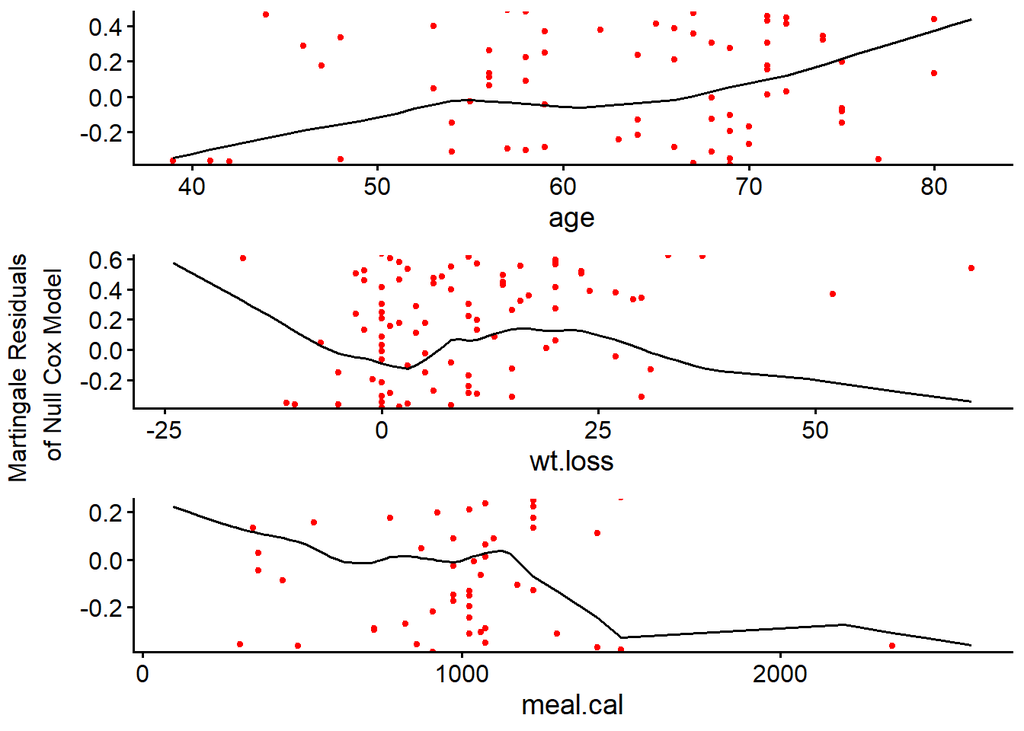

```r
ggcoxfunctional(Surv(time, status) ~ age + wt.loss + meal.cal, data = lung_imputed10)
```

## **Résultats**

```r
library(parameters)

parameters(cox_imput_multiple, exponentiate = TRUE) #les résultats du modèle de cox (avec imputation multiple)
```

```
## # Fixed Effects
##
## Parameter | Coefficient |       SE |       95% CI |     z |     df |     p
## --------------------------------------------------------------------------
## sex       |        0.55 |     0.10 | [0.38, 0.79] | -3.22 | 154.56 | 0.002
## age       |        1.01 |     0.01 | [0.98, 1.03] |  0.56 | 153.28 | 0.574
## wt loss   |        0.99 | 6.99e-03 | [0.97, 1.00] | -1.78 | 145.70 | 0.077
## meal cal  |        1.00 | 2.70e-04 | [1.00, 1.00] | -0.37 | 102.27 | 0.712
## ph ecog   |        1.82 |     0.39 | [1.19, 2.77] |  2.81 | 154.87 | 0.006
## ph karno  |        1.00 |     0.01 | [0.98, 1.02] |  0.27 | 155.48 | 0.789
## pat karno |        0.99 | 7.52e-03 | [0.97, 1.00] | -1.41 | 151.28 | 0.162
```

```r
#une présentation plus synthétique
#coefficient c'est le HR
```

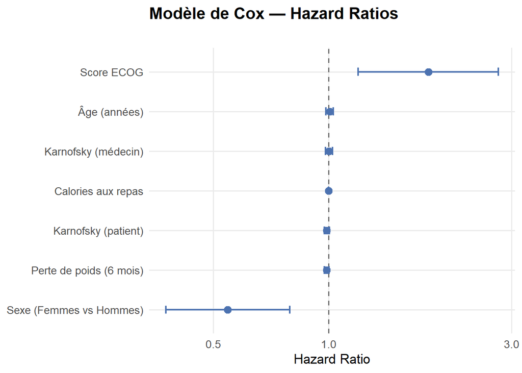

```r
ggplot(plot_cox,
       aes(x = estimate, y = reorder(label, estimate))) +
  geom_vline(xintercept = 1, linetype = "dashed", color = "grey40") +
  geom_errorbarh(aes(xmin = conf.low, xmax = conf.high),
                 height = 0.2, color = "#4C72B0", linewidth = 0.8) +
  geom_point(size = 3, color = "#4C72B0") +
  scale_x_log10() +
  labs(
    title    = "Modèle de Cox — Hazard Ratios",
    subtitle = "",
    x        = "Hazard Ratio",
    y        = NULL
  ) +
  theme_minimal(base_size = 13) +
  theme(
    panel.grid.minor = element_blank(),
    plot.title       = element_text(face = "bold")
  )
```

## **Conclusion**

L’analyse de survie par un modèle de régression de Cox stratifié sur l’institution (ajusté après imputation multiple) met en évidence deux facteurs pronostiques chez les patients atteints de cancer du poumon :

1. Les femmes présentent un avantage de survie statistiquement significatif par rapport aux hommes. Toutes choses étant égales par ailleurs, le risque de décès chez les femmes est réduit de 45 %.
2. Une augmentation d’un point sur l’échelle ECOG (traduisant une dégradation de l’autonomie) est associée à une hausse du risque de décès de 82 %.